# BaseFirthFlic1117

Author

sw

## Installing the Packages and the Libraries

Note: I had to create a cran repository first. I could have used renv::init..but I chose a 1 liner

```
ResourceSelection 0.3-6      2023-06-27
```

```
system might not have X11 capabilities; in case of errors when using dfSummary(), set st_options(use.x11 = FALSE)
```

[output not shown]

[output cut: 62 more lines]

Coding the Predictors and Omitting irrelevant values

Because we are using Logistic Regression a Quantitative tool, all predictors and the outcome variable must also be coded to quantitative equivalents. We also had to deal with N/A…so there were predictor variables in the dataset that had “N/A”, Unknown, Children and Other. It would be easier to recode all the irrelevant values as “N/A” and get rid of them all at the same time. We also recoded gender to 1 as male and 2 as female. We also limited the bmi predictor to 2 places after the decimal.Finally we recoded all text categorical variables into numeric variables.

Showing Descriptive Statistics for all variables, Mean, Std Deviation, and Interquartile Range

```
Data Frame Summary
strokeclean
Dimensions: 3357 x 11
Duplicates: 0

----------------------------------------------------------------------------------------------------------------------
No   Variable            Stats / Values             Freqs (% of Valid)     Graph                  Valid      Missing
---- ------------------- -------------------------- ---------------------- ---------------------- ---------- ---------
1    gender              Min  : 1                   1 : 1305 (38.9%)       IIIIIII                3357       0
     [numeric]           Mean : 1.6                 2 : 2052 (61.1%)       IIIIIIIIIIII           (100.0%)   (0.0%)
                         Max  : 2

2    age                 Mean (sd) : 49.4 (18.3)    70 distinct values             . : .          3357       0
     [numeric]           min < med < max:                                    . . : : : : .   :    (100.0%)   (0.0%)
                         13 < 50 < 82                                        : : : : : : : : :
                         IQR (CV) : 28 (0.4)                               : : : : : : : : : :
                                                                           : : : : : : : : : :

3    hypertension        Min  : 0                   0 : 2949 (87.8%)       IIIIIIIIIIIIIIIII      3357       0
     [numeric]           Mean : 0.1                 1 :  408 (12.2%)       II                     (100.0%)   (0.0%)
                         Max  : 1

4    heart_disease       Min  : 0                   0 : 3151 (93.9%)       IIIIIIIIIIIIIIIIII     3357       0
     [numeric]           Mean : 0.1                 1 :  206 ( 6.1%)       I                      (100.0%)   (0.0%)
                         Max  : 1

5    ever_married        Min  : 1                   1 : 2599 (77.4%)       IIIIIIIIIIIIIII        3357       0
     [numeric]           Mean : 1.2                 2 :  758 (22.6%)       IIII                   (100.0%)   (0.0%)
                         Max  : 2

6    work_type           Mean (sd) : 2 (0.6)        1 :  514 (15.3%)       III                    3357       0
     [numeric]           min < med < max:           2 : 2200 (65.5%)       IIIIIIIIIIIII          (100.0%)   (0.0%)
                         1 < 2 < 4                  3 :  629 (18.7%)       III
                         IQR (CV) : 0 (0.3)         4 :   14 ( 0.4%)

7    Residence_type      Min  : 1                   1 : 1709 (50.9%)       IIIIIIIIII             3357       0
     [numeric]           Mean : 1.5                 2 : 1648 (49.1%)       IIIIIIIII              (100.0%)   (0.0%)
                         Max  : 2

8    avg_glucose_level   Mean (sd) : 108.4 (47.9)   2861 distinct values     :                    3357       0
     [numeric]           min < med < max:                                  . :                    (100.0%)   (0.0%)
                         55.1 < 92.3 < 271.7                               : : :
                         IQR (CV) : 39 (0.4)                               : : :
                                                                           : : : : . . . . .

9    bmi                 Mean (sd) : 30.4 (7.2)     364 distinct values      . :                  3357       0
     [numeric]           min < med < max:                                    : :                  (100.0%)   (0.0%)
                         11.5 < 29.2 < 92                                    : :
                         IQR (CV) : 8.8 (0.2)                                : : :
                                                                           . : : : .

10   smoking_status      Mean (sd) : 1.7 (0.8)      1 : 1798 (53.6%)       IIIIIIIIII             3357       0
     [numeric]           min < med < max:           2 :  824 (24.5%)       IIII                   (100.0%)   (0.0%)
                         1 < 1 < 3                  3 :  735 (21.9%)       IIII
                         IQR (CV) : 1 (0.5)

11   stroke              1. 0                       3177 (94.6%)           IIIIIIIIIIIIIIIIII     3357       0
     [factor]            2. 1                        180 ( 5.4%)           I                      (100.0%)   (0.0%)
----------------------------------------------------------------------------------------------------------------------
```

Descriptive Statistics

| Mean_Age | Range_Age | SD_Age | Mean_BMI | Range_BMI | SD_BMI | Mean_AvgGlucoseLvl | Range_AvgGlucoseLvl | SD_AvgGlucoseLvl |
| --- | --- | --- | --- | --- | --- | --- | --- | --- |
| 49.38725 | 13 - 82 | 18.31051 | 30.43953 | 11.5 - 92 | 7.249738 | 108.4443 | 55.12 - 271.74 | 47.92139 |

Looking at the distribution of all the predictor indicators and the outcome indicator with Histograms

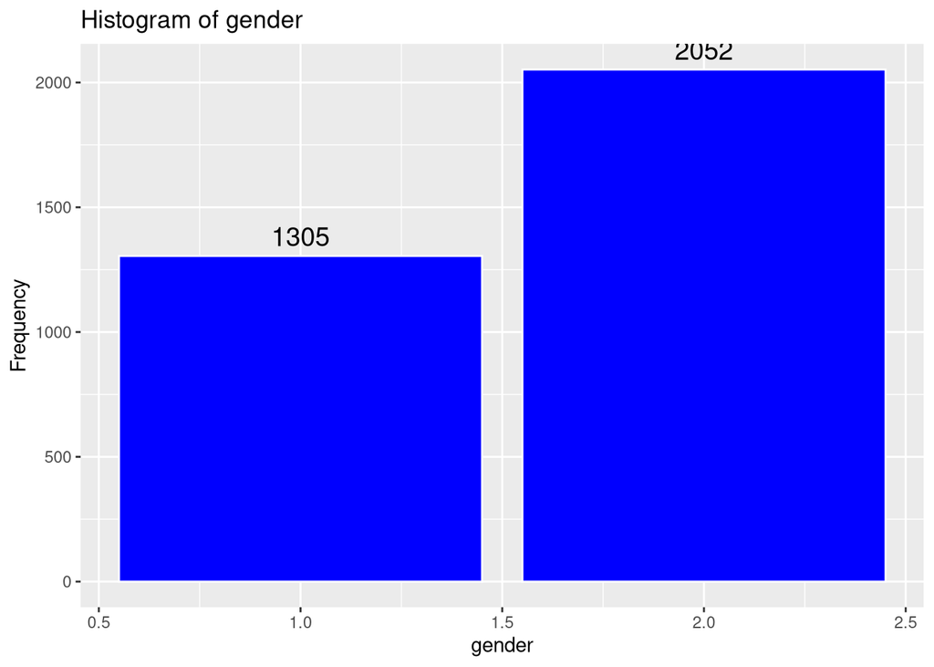

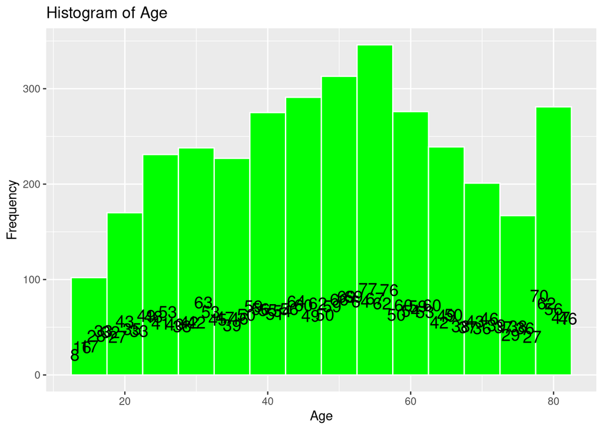

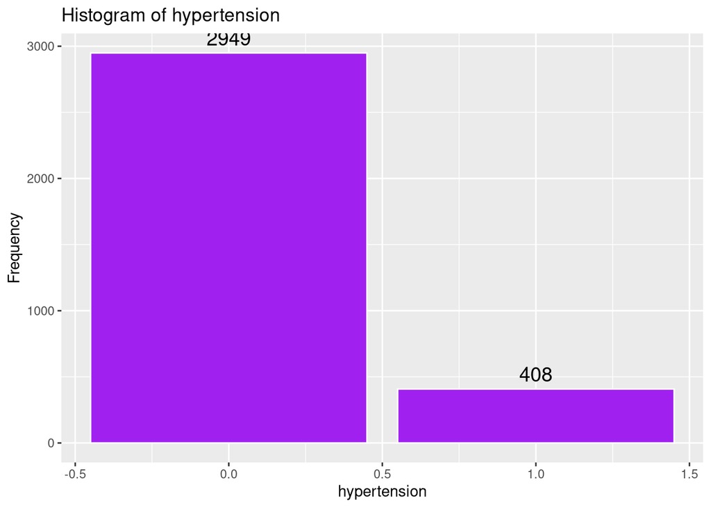

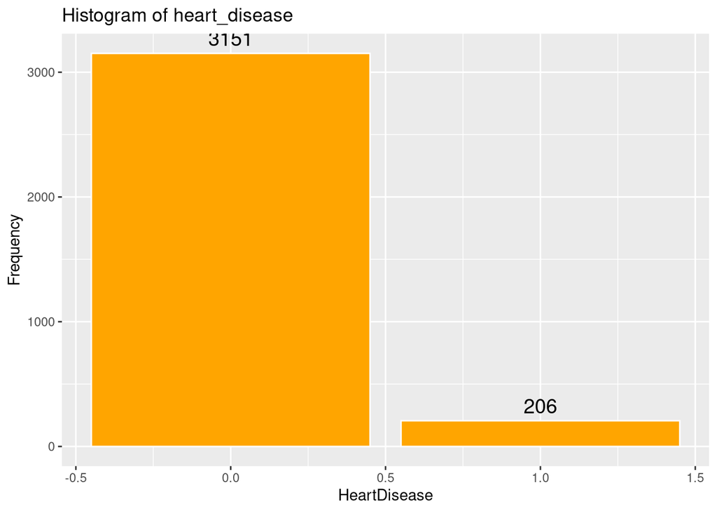

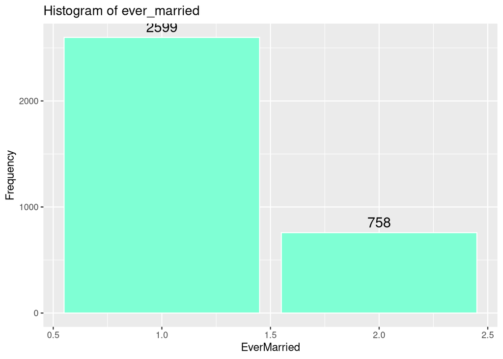

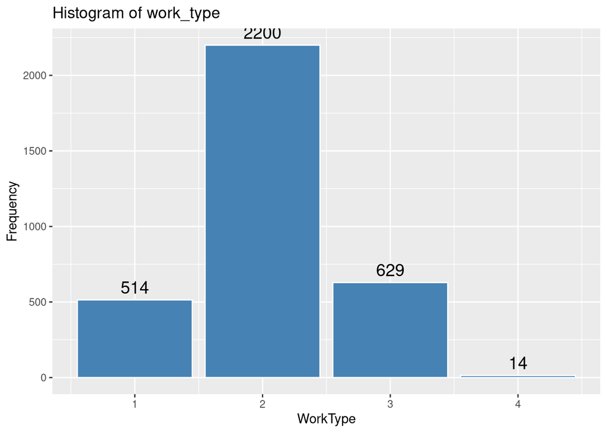

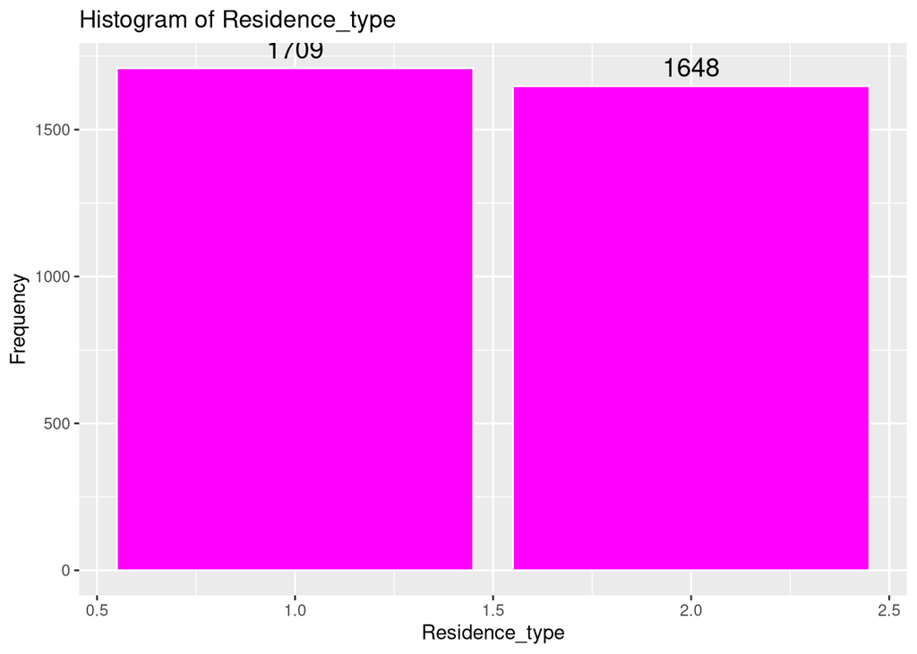

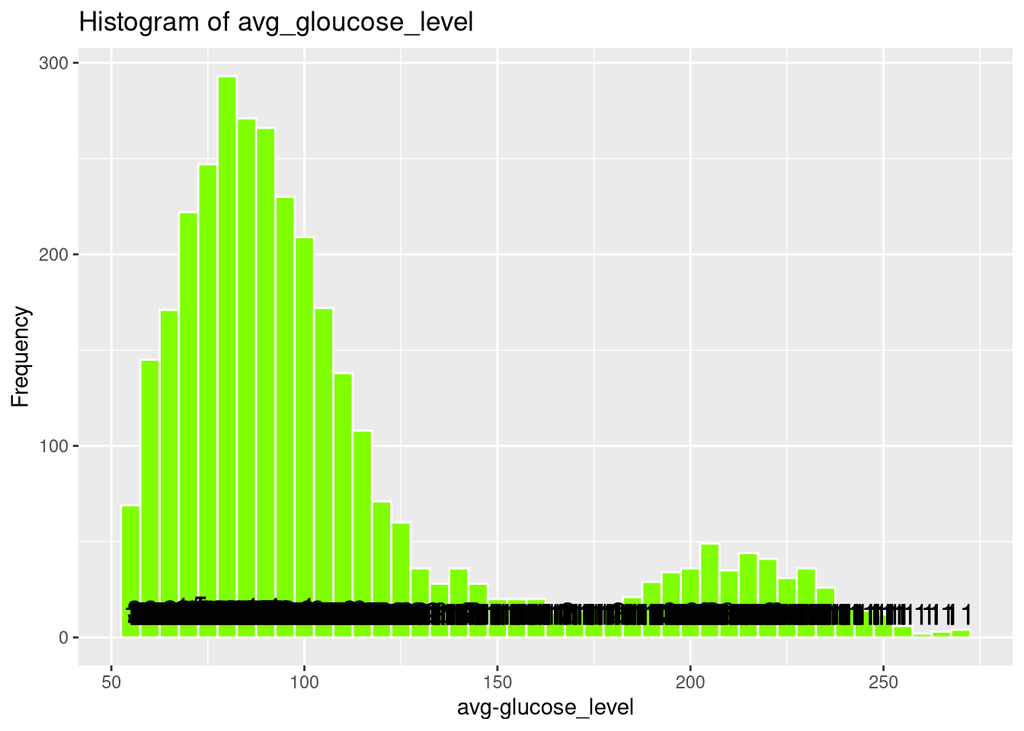

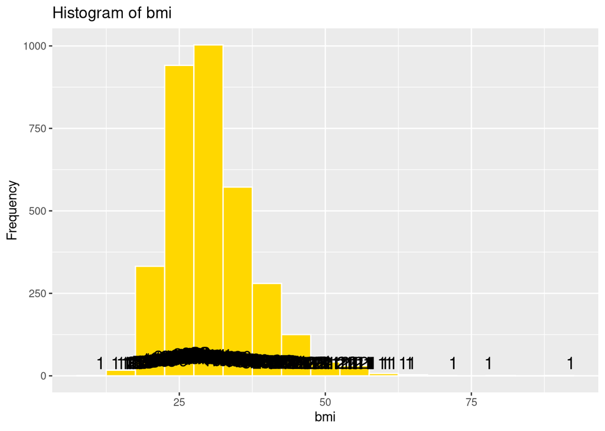

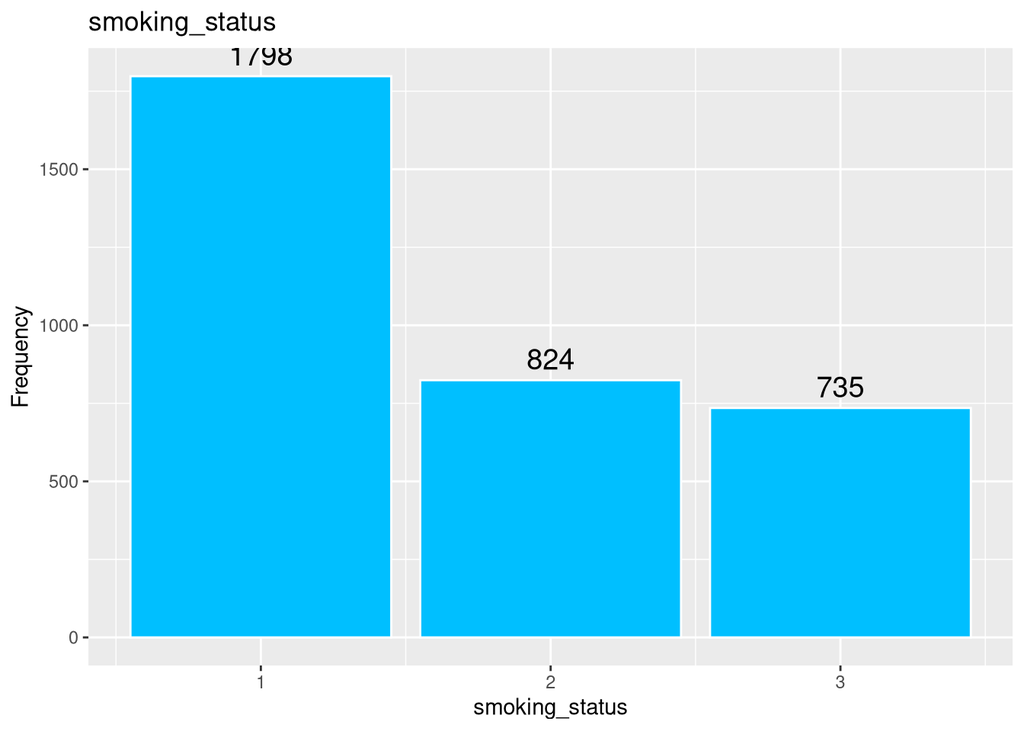

[figure not shown]

### **Review of Logistic Regression**

Logistic regression is a statistical modeling technique that predicts the probability of a binary outcome (such as 0 or 1) using one or more independent variables.

#### Mathematics Behind Logistic Regression

The key idea is to model the **log odds** (also called the logit) of the probability of the event as a linear function of the predictors:

- The key idea is to model the **log odds** (also called the logit) of the probability of the event as a linear function of the predictors:

#### Core Concepts

(2) The **logit** transformation (natural log of the odds) turns this nonlinear problem into a linear one, so standard linear modeling techniques can be used for estimation.

(3) Coefficients (β) are commonly estimated using **maximum likelihood** methods, not ordinary least squares.

A comparison between Logistic Regression and Multiple Regression is shown below

| Feature | Multiple Regression | Logistic Regression |
| --- | --- | --- |
| Outcome variable type | Continuous (real numbers) | Categorical/Binary (e.g., 0 or 1) |
| Example prediction | Predicting house prices | Predicting disease presence/absence |
| Model equation | Linear combination of predictors | Log odds/logit (S-shaped curve: logistic function) |
| Estimation method | Least squares | Maximum likelihood |
| Output type | Actual values (e.g., $125,000) | Probability of being in a category (e.g., 87%) |
| Usage | Continuous outcome (income, cost, score) | Categorical outcome (yes/no, 0/1) |

As you can see the prediction of having a stroke or not with the outcome variable clearly shows we should use Logistic Regression. Note. The predictor variables can be either categorical or continuous. Its the outcome variable that is critical in choosing.

But before we can run the all the models of Logistic Regression, there are 4 assumptions of Logistic Regression that we need to determine if the dataset and models can run without violating any or all of the assumptions of Logistic Regression. Note testing the assumptions are done for numerical predictors only statistically speaking. Categorical predictors are tested visually with the histograms above.

```
[1] 1 0
Levels: 0 1
```

```
'data.frame':   3357 obs. of  14 variables:
 $ gender              : num  1 1 2 2 1 1 2 2 2 2 ...
 $ age                 : num  67 80 49 79 81 74 69 81 61 54 ...
 $ hypertension        : num  0 0 0 1 0 1 0 1 0 0 ...
 $ heart_disease       : num  1 1 0 0 0 1 0 0 1 0 ...
 $ ever_married        : num  1 1 1 1 1 1 2 1 1 1 ...
 $ work_type           : num  2 2 2 3 2 2 2 2 1 2 ...
 $ Residence_type      : num  1 2 1 2 1 2 1 2 2 1 ...
 $ avg_glucose_level   : num  229 106 171 174 186 ...
 $ bmi                 : num  36.6 32.5 34.4 24 29 27.4 22.8 29.7 36.8 27.3 ...
 $ smoking_status      : num  2 1 3 1 2 1 1 1 3 3 ...
 $ stroke              : Factor w/ 2 levels "0","1": 2 2 2 2 2 2 2 2 2 2 ...
 $ ageadj              : num  81 94 63 93 95 88 83 95 75 68 ...
 $ avg_glucose_leveladj: num  285 162 227 230 242 ...
 $ bmiadj              : num  49.1 45 46.9 36.5 41.5 39.9 35.3 42.2 49.3 39.8 ...
 - attr(*, "na.action")= 'omit' Named int [1:1753] 2 9 10 14 20 24 28 30 32 39 ...
  ..- attr(*, "names")= chr [1:1753] "2" "9" "10" "14" ...
```

```
                     gender   age hypertension heart_disease ever_married
gender                 1.00 -0.06        -0.04         -0.10         0.03
age                   -0.06  1.00         0.26          0.26        -0.49
hypertension          -0.04  0.26         1.00          0.11        -0.11
heart_disease         -0.10  0.26         0.11          1.00        -0.07
ever_married           0.03 -0.49        -0.11         -0.07         1.00
work_type              0.01  0.14         0.05          0.03        -0.02
Residence_type        -0.01 -0.02         0.00         -0.01         0.01
avg_glucose_level     -0.07  0.24         0.17          0.14        -0.12
bmi                   -0.02  0.04         0.13          0.00        -0.13
smoking_status        -0.08  0.03        -0.01          0.06        -0.06
ageadj                -0.06  1.00         0.26          0.26        -0.49
avg_glucose_leveladj  -0.07  0.24         0.17          0.14        -0.12
bmiadj                -0.02  0.04         0.13          0.00        -0.13
                     work_type Residence_type avg_glucose_level   bmi
gender                    0.01          -0.01             -0.07 -0.02
age                       0.14          -0.02              0.24  0.04
hypertension              0.05           0.00              0.17  0.13
heart_disease             0.03          -0.01              0.14  0.00
ever_married             -0.02           0.01             -0.12 -0.13
work_type                 1.00          -0.01              0.03 -0.02
Residence_type           -0.01           1.00              0.01  0.01
avg_glucose_level         0.03           0.01              1.00  0.16
bmi                      -0.02           0.01              0.16  1.00
smoking_status           -0.02          -0.04              0.01  0.03
ageadj                    0.14          -0.02              0.24  0.04
avg_glucose_leveladj      0.03           0.01              1.00  0.16
bmiadj                   -0.02           0.01              0.16  1.00
                     smoking_status ageadj avg_glucose_leveladj bmiadj
gender                        -0.08  -0.06                -0.07  -0.02
age                            0.03   1.00                 0.24   0.04
hypertension                  -0.01   0.26                 0.17   0.13
heart_disease                  0.06   0.26                 0.14   0.00
ever_married                  -0.06  -0.49                -0.12  -0.13
work_type                     -0.02   0.14                 0.03  -0.02
Residence_type                -0.04  -0.02                 0.01   0.01
avg_glucose_level              0.01   0.24                 1.00   0.16
bmi                            0.03   0.04                 0.16   1.00
smoking_status                 1.00   0.03                 0.01   0.03
ageadj                         0.03   1.00                 0.24   0.04
```

[output cut: 34 more lines]

```
bmiadj               0.3243    0.5689         0.0000            0.0000
                     smoking_status ageadj avg_glucose_leveladj bmiadj
gender               0.0000         0.0012 0.0000               0.2487
age                  0.0448         0.0000 0.0000               0.0144
hypertension         0.7537         0.0000 0.0000               0.0000
heart_disease        0.0005         0.0000 0.0000               0.8185
ever_married         0.0009         0.0000 0.0000               0.0000
work_type            0.3764         0.0000 0.0467               0.3243
Residence_type       0.0208         0.3076 0.6427               0.5689
avg_glucose_level    0.7679         0.0000 0.0000               0.0000
bmi                  0.0925         0.0144 0.0000               0.0000
smoking_status                      0.0448 0.7679               0.0925
ageadj               0.0448                0.0000               0.0144
avg_glucose_leveladj 0.7679         0.0000                      0.0000
bmiadj               0.0925         0.0144 0.0000
```

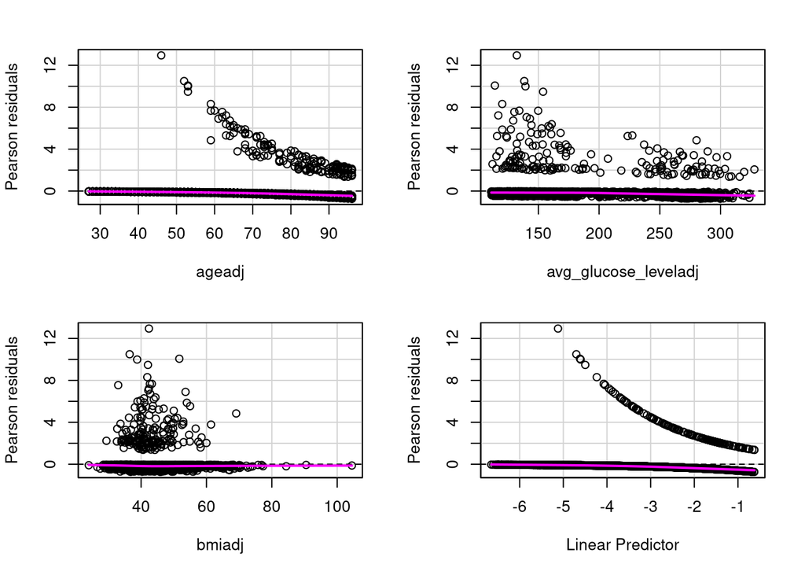

```
                     Test stat Pr(>|Test stat|)
ageadj                  1.9958           0.1577
avg_glucose_leveladj    0.0070           0.9331
bmiadj                  0.3549           0.5514
```

```
Model :
stroke ~ ageadj + avg_glucose_leveladj + bmiadj
```

```
                     gender   age hypertension heart_disease ever_married
gender                 1.00 -0.06        -0.04         -0.10         0.03
age                   -0.06  1.00         0.26          0.26        -0.49
hypertension          -0.04  0.26         1.00          0.11        -0.11
heart_disease         -0.10  0.26         0.11          1.00        -0.07
ever_married           0.03 -0.49        -0.11         -0.07         1.00
work_type              0.01  0.14         0.05          0.03        -0.02
Residence_type        -0.01 -0.02         0.00         -0.01         0.01
avg_glucose_level     -0.07  0.24         0.17          0.14        -0.12
bmi                   -0.02  0.04         0.13          0.00        -0.13
smoking_status        -0.08  0.03        -0.01          0.06        -0.06
ageadj                -0.06  1.00         0.26          0.26        -0.49
avg_glucose_leveladj  -0.07  0.24         0.17          0.14        -0.12
bmiadj                -0.02  0.04         0.13          0.00        -0.13
                     work_type Residence_type avg_glucose_level   bmi
gender                    0.01          -0.01             -0.07 -0.02
age                       0.14          -0.02              0.24  0.04
hypertension              0.05           0.00              0.17  0.13
heart_disease             0.03          -0.01              0.14  0.00
ever_married             -0.02           0.01             -0.12 -0.13
work_type                 1.00          -0.01              0.03 -0.02
Residence_type           -0.01           1.00              0.01  0.01
avg_glucose_level         0.03           0.01              1.00  0.16
bmi                      -0.02           0.01              0.16  1.00
smoking_status           -0.02          -0.04              0.01  0.03
ageadj                    0.14          -0.02              0.24  0.04
avg_glucose_leveladj      0.03           0.01              1.00  0.16
bmiadj                   -0.02           0.01              0.16  1.00
                     smoking_status ageadj avg_glucose_leveladj bmiadj
gender                        -0.08  -0.06                -0.07  -0.02
age                            0.03   1.00                 0.24   0.04
hypertension                  -0.01   0.26                 0.17   0.13
heart_disease                  0.06   0.26                 0.14   0.00
ever_married                  -0.06  -0.49                -0.12  -0.13
work_type                     -0.02   0.14                 0.03  -0.02
Residence_type                -0.04  -0.02                 0.01   0.01
avg_glucose_level              0.01   0.24                 1.00   0.16
bmi                            0.03   0.04                 0.16   1.00
smoking_status                 1.00   0.03                 0.01   0.03
ageadj                         0.03   1.00                 0.24   0.04
```

[output cut: 34 more lines]

```
bmiadj               0.3243    0.5689         0.0000            0.0000
                     smoking_status ageadj avg_glucose_leveladj bmiadj
gender               0.0000         0.0012 0.0000               0.2487
age                  0.0448         0.0000 0.0000               0.0144
hypertension         0.7537         0.0000 0.0000               0.0000
heart_disease        0.0005         0.0000 0.0000               0.8185
ever_married         0.0009         0.0000 0.0000               0.0000
work_type            0.3764         0.0000 0.0467               0.3243
Residence_type       0.0208         0.3076 0.6427               0.5689
avg_glucose_level    0.7679         0.0000 0.0000               0.0000
bmi                  0.0925         0.0144 0.0000               0.0000
smoking_status                      0.0448 0.7679               0.0925
ageadj               0.0448                0.0000               0.0144
avg_glucose_leveladj 0.7679         0.0000                      0.0000
bmiadj               0.0925         0.0144 0.0000
```

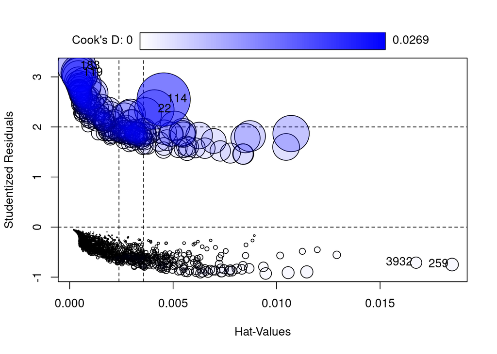

```
        StudRes          Hat       CookD
22    2.3495313 0.0040917969 0.014793349
114   2.5500288 0.0045425981 0.026906139
119   3.0778217 0.0004677603 0.012890963
183   3.2110607 0.0003364260 0.014101935
259  -0.7488292 0.0184781611 0.001532740
3932 -0.7113787 0.0167417735 0.001232964
```

```
              ageadj avg_glucose_leveladj               bmiadj
            1.070909             1.081460             1.101382
```

```
    Hosmer and Lemeshow goodness of fit (GOF) test

data:  model4$y, fitted(model4)
X-squared = 8.8522, df = 8, p-value = 0.3549
```

```
$Models

Model: "glm, stroke ~ ageadj + avg_glucose_leveladj + bmiadj, binomial, fourAdj"
Null:  "glm, stroke ~ 1, binomial, fourAdj"

$Pseudo.R.squared.for.model.vs.null
                             Pseudo.R.squared
McFadden                            0.1713030
Cox and Snell (ML)                  0.0691131
Nagelkerke (Cragg and Uhler)        0.2022700

$Likelihood.ratio.test
 Df.diff LogLik.diff  Chisq   p.value
      -3     -120.21 240.42 7.721e-52

$Number.of.observations

Model: 3357
Null:  3357

$Messages
[1] "Note: For models fit with REML, these statistics are based on refitting with ML"

$Warnings
[1] "None"
```

The three different models of Logistic Regression: Baseline, Firth and Flic Corrections. We are creating 3 different models to really test to see if the dataset had a stroke percentage that is less than the real percentage of stroke to population ratio in the US. Because this is a so called “rare event” Firth regression takes this into account as does its refinement FLIC.

Creating Youdens J. Youden’s J is a good way to look at how well each model balances sensitivity and selectivity. The closer to the curve, a Youden’s J is the better the model can distinguish between sensitiviy and selectivity.

The Three Types of Prediction with 0.5 for consistency

The Function to Compute Metrics

Intialize Results. We have to initialize results before calling the model

Print Results

```
== Baseline Logistic Regression ==
```

```
$confusion
          Reference
Prediction    0    1
         0 3177  178
         1    0    2

$precision
Pos Pred Value
             1

$recall
Sensitivity
 0.01111111

$f1
Pos Pred Value
    0.02197802

$auc
Area under the curve: 0.8285

$roc_obj

Call:
roc.default(response = labels, predictor = as.numeric(prob))

Data: as.numeric(prob) in 3177 controls (labels 0) < 180 cases (labels 1).
Area under the curve: 0.8285
```

```
Youden's J (optimal threshold):
```

```
   threshold sensitivity specificity   youden
1 0.06934436   0.7444444   0.7777778 1.522222
```

```
== Firth Logistic Regression ==
```

```
$confusion
          Reference
Prediction    0    1
         0 3176  178
         1    1    2

$precision
Pos Pred Value
     0.6666667

$recall
Sensitivity
 0.01111111

$f1
Pos Pred Value
    0.02185792

$auc
Area under the curve: 0.8285

$roc_obj

Call:
roc.default(response = labels, predictor = as.numeric(prob))

Data: as.numeric(prob) in 3177 controls (labels 0) < 180 cases (labels 1).
Area under the curve: 0.8285
```

```
Youden's J (optimal threshold):
```

```
   threshold sensitivity specificity   youden
1 0.07100345   0.7444444   0.7777778 1.522222
```

```
== FLIC Logistic Regression ==
```

```
$confusion
          Reference
Prediction    0    1
         0 3177  178
         1    0    2

$precision
Pos Pred Value
             1

$recall
Sensitivity
 0.01111111

$f1
Pos Pred Value
    0.02197802

$auc
Area under the curve: 0.8285

$roc_obj

Call:
roc.default(response = labels, predictor = as.numeric(prob))

Data: as.numeric(prob) in 3177 controls (labels 0) < 180 cases (labels 1).
Area under the curve: 0.8285
```

```
Youden's J (optimal threshold):
```

```
   threshold sensitivity specificity   youden
1 0.06935441   0.7444444   0.7777778 1.522222
```

Plot the ROC curves and Annotate Youden’s J on each of the Curves

```
Area under the curve: 0.8285
```

```
Area under the curve: 0.8285
```

```
Area under the curve: 0.8285
```

[figure not shown]

Plot the Confusion Matrices

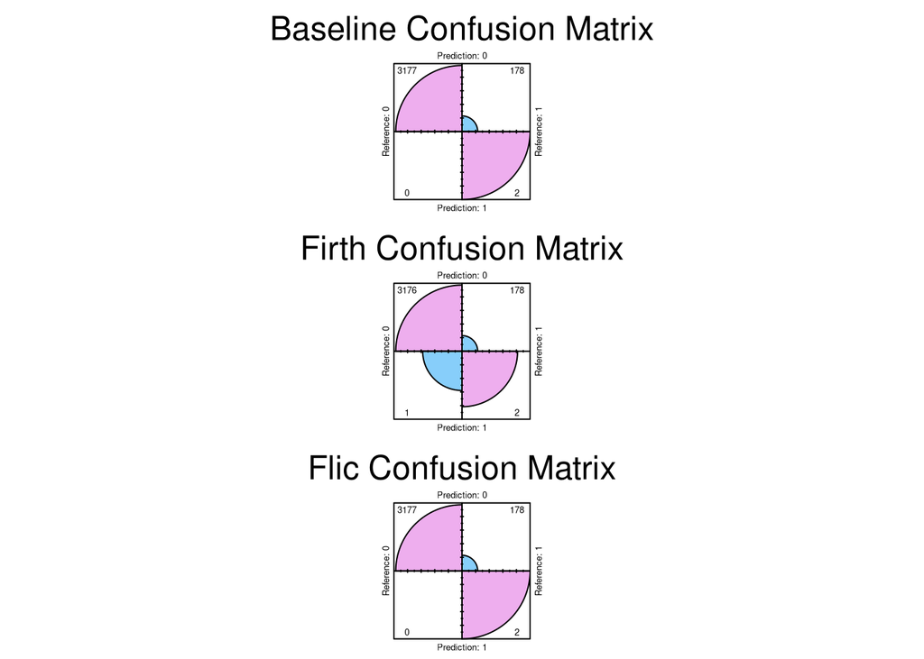